# R: Review

Hai Liang - hailiang@cuhk.edu.hk

# Introduction

This is a brief introduction to R for both programming and data analysis.

R is not the only tool for computational studies. Sometimes, it is not the best one either. We choose R for instruction just because we, social scientists, find it’s easy to learn. It is not a statistical package with programing functions.

When we are talking about computational methods, two techniques are involved: programming and data analysis. Programming is different from data analysis. They are two different things, though highly correlated in computational studies. Many students can’t tell the differences at the very beginning of learning. They read papers from computer science, statistics, and social sciences. The topics are similar but may have fundamental differences in techniques.

Programmers can develop fantastic applications, such as MS word and PPT. They possibly know nothing about data analysis and didn’t take a statistics course.

On the other side, data analyst may have little knowledge on coding. I guess most of you may have some basic knowledge about statistics, but can’t write a statistical program using C, JAVA, or Python. You do statistical analysis by simply clicking the buttons in SPSS or STATA. If SPSS doesn’t provide a function you needed, you have no idea.

In this sense, Python is a good tool for programming, while R is good for data analysis. Data analysis doesn’t merely refer to statistics. Machine learning and other data mining models could not be statistical (that means we don’t infer parameters with distribution assumptions).

In section I, this tutorial will focus on programming. In section II, this tutorial will talk about data analysis.

The first step to use R is to set the working directory. Your working directory is the folder on your computer in which you are currently working. When you ask R to open a file, it will look in the working directory for this file, and when you tell R to save a data file or figure, it will save it in the working directory.

```r
# setwd("/R Review") # set a working directory
```

R can do many statistical and data analyses. They are organized in so-called packages or libraries. With the standard installation, most common packages are installed.

```r
#install.packages("tm")
#library("tm") # load a library (remember library names)
#help(package="tm")
```

# Section I: Programming Basics

## 1.1. I/O

How to import data from text, csv files into R?

```r
#data = read.table(file="authorlist.txt",stringsAsFactors=F)
#data = read.csv(file="authorlist.csv",stringsAsFactors=F)
#write.table(data,file="authorlist.txt")
#write.csv(data,file="authorlist.csv")
```

It’s also possible to import data from SPSS or STATA files, even you haven’t installed the software. We use the foreign library.

```r
library(foreign)
#read.spss(file="authorlist.sav", to.data.frame = T)
#read.dta(file="authorlist.dta")
#save(data,file="")
#load("sample.Rdata")
```

## 1.2. Basic syntax

Do some basic calculations.

```r
1+2
```

```
## [1] 3
```

```r
1-2
```

```
## [1] -1
```

```r
1*2
```

```
## [1] 2
```

```r
1/2
```

```
## [1] 0.5
```

```r
sqrt(2) # squared root of 2
```

```
## [1] 1.414214
```

```r
2^2 # 2 squared
```

```
## [1] 4
```

We can define a variable and assign a value to it.

```r
height = 180 # instead of using the equation symbol, it is equivalent to use the arrow symbol.
weight = 50
print (height*weight)
```

```
## [1] 9000
```

or alternatively, we assign the result to a new variable

```r
nv = height*weight
nv # instead of print(nv)
```

```
## [1] 9000
```

R has some generic functions that we can use them directly. For example, calculating the sum and mean of a series of numbers.

```r
sum(c(1,2,3))
```

```
## [1] 6
```

```r
mean(c(1,2,3))
```

```
## [1] 2
```

If you don’t know how to use a function, you can use the help() function and check the examples. For example

```r
help(sum) # or equivalently
```

```
## starting httpd help server ...
```

```
##  done
```

```r
?sum
```

## 1.3. Data types

There are 3 general modes of data in R: string/characters, numbers, and logical.

```r
string = "I am xxx"
string
```

```
## [1] "I am xxx"
```

```r
# use class or typeof to determine the type of a variable
class(string)
```

```
## [1] "character"
```

```r
typeof(string)
```

```
## [1] "character"
```

```r
number = 5
number
```

```
## [1] 5
```

Another important data type is the logical type. There are two predefined variables:TRUE and FALSE

```r
logic = TRUE
logic
```

```
## [1] TRUE
```

```r
missing = NA
missing
```

```
## [1] NA
```

## 1.4. Data structures

To learn any programming languages, a shortcut is to learn the core elements. Fortunately, most programming languages share very similar core elements. They are data structure, conditional expressions, loops, and functions.

Four types of data structure are commonly used in R: vector, matrix, data frame, and list. The first is vector. Vector is a list of values. These values could be numeric, logic, or string.

```r
# using c (c is a function) to generate a new vector
v = c(1,7,9,10)
v
```

```
## [1]  1  7  9 10
```

The data type of vector values must be the same. If numbers,characters,and missing value are assigned together, what will happen?

```r
v2 = c(1,7,NA,"hi")
v2
```

```
## [1] "1"  "7"  NA   "hi"
```

```r
# to access an element in the vector
v[-2]
```

```
## [1]  1  9 10
```

```r
# vector elements can have names
names(v)
```

```r
# assign names
names(v) = c("First","Second","Third","Fourth")
names(v)
```

```
## [1] "First"  "Second" "Third"  "Fourth"
```

We can apply mathematical calculations directly to vector. We can multiply a vector by a number, calculate the sqrt of each elements in the vector.

```r
v*2
```

```
##  First Second  Third Fourth
##      2     14     18     20
```

```r
sqrt(v)
```

```
##    First   Second    Third   Fourth
## 1.000000 2.645751 3.000000 3.162278
```

The second structure is matrix. Matrix is a collection of vectors, organized in rows and columns. Values in a matrix should be in the same data type. Each column or row is a vector. We use the matrix function to generate a matrix with 5 cols and 5 rows. Values are integers from 1 to 25.

```r
m = matrix(1:25,5,5)
```

Similar to vector, we could do simple maths.

```r
m+2
```

```
##      [,1] [,2] [,3] [,4] [,5]
## [1,]    3    8   13   18   23
## [2,]    4    9   14   19   24
## [3,]    5   10   15   20   25
## [4,]    6   11   16   21   26
## [5,]    7   12   17   22   27
```

```r
m+m
```

```
##      [,1] [,2] [,3] [,4] [,5]
## [1,]    2   12   22   32   42
## [2,]    4   14   24   34   44
## [3,]    6   16   26   36   46
## [4,]    8   18   28   38   48
## [5,]   10   20   30   40   50
```

```r
m%*%m # matrix nultiplication
```

```
##      [,1] [,2] [,3] [,4] [,5]
## [1,]  215  490  765 1040 1315
## [2,]  230  530  830 1130 1430
## [3,]  245  570  895 1220 1545
## [4,]  260  610  960 1310 1660
## [5,]  275  650 1025 1400 1775
```

We can combine two matrices by cols or rows.

```r
cbind(m,m)
```

```
##      [,1] [,2] [,3] [,4] [,5] [,6] [,7] [,8] [,9] [,10]
## [1,]    1    6   11   16   21    1    6   11   16    21
## [2,]    2    7   12   17   22    2    7   12   17    22
## [3,]    3    8   13   18   23    3    8   13   18    23
## [4,]    4    9   14   19   24    4    9   14   19    24
## [5,]    5   10   15   20   25    5   10   15   20    25
```

```r
rbind(m,m)
```

```
##       [,1] [,2] [,3] [,4] [,5]
##  [1,]    1    6   11   16   21
##  [2,]    2    7   12   17   22
##  [3,]    3    8   13   18   23
##  [4,]    4    9   14   19   24
##  [5,]    5   10   15   20   25
##  [6,]    1    6   11   16   21
##  [7,]    2    7   12   17   22
##  [8,]    3    8   13   18   23
##  [9,]    4    9   14   19   24
## [10,]    5   10   15   20   25
```

```r
# access a matrix element
m[2,3] = "hi"
```

A data frame is a matrix, while columns could be of all different data types.

```r
v1=c(1,7,6,3,2)
v2=c(T,F,T,F,T)
v3=c("Y","N","Y","N","Y")
d = data.frame(v1,v2,v3,stringsAsFactors=F) # create use data.frame
```

A list is a collection of all data structure.

```r
l = list(v,m,d)
names(l)
```

```r
l[[3]]
```

| v1 | v2 | v3 |
| --- | --- | --- |
| 1 | TRUE | Y |
| 7 | FALSE | N |
| 6 | TRUE | Y |
| 3 | FALSE | N |
| 2 | TRUE | Y |

## 1.5. Programming tools

I will introduce 3 programming tools: if…else expression (which is one of the conditional expressions), for and while loop expressions, and user defined functions.

Task: input a number, if the value is larger than or equal to 100, print “High Value”, if the value is less than 100 and larger than or equal to 50, print “Middle Value”, if less than 50, print “Low Value”.

```r
x = 95
if (x>=100){
  print("High Value")
} else if (x>=50&x<100){
  print("Middle Value")
} else {
  print("Low Value")
}
```

```
## [1] "Middle Value"
```

Task: calculate the number of characters in our names. We use nchar() for each name.That means we will use the nchar() function many times.

```r
names=c("Hai","Jonanthan","Zhenzhen","Qinjie")
for (name in names) {
  N = nchar(name)
  print (paste(name,":",N,"characters"))
}
```

```
## [1] "Hai : 3 characters"
## [1] "Jonanthan : 9 characters"
## [1] "Zhenzhen : 8 characters"
## [1] "Qinjie : 6 characters"
```

or alternatively, loop over the index of the vector:

```r
for (i in 1:4) {
  N = nchar(name[i])
  print (paste(name[i],":",N,"characters"))
}
```

```
## [1] "Qinjie : 6 characters"
## [1] "NA : NA characters"
## [1] "NA : NA characters"
## [1] "NA : NA characters"
```

or use while instead of loop

```r
i=1
while (i<=4){
  N = nchar(name[i])
  print (paste(name[i],":",N,"characters"))
  i=i+1 #counter
}
```

```
## [1] "Qinjie : 6 characters"
## [1] "NA : NA characters"
## [1] "NA : NA characters"
## [1] "NA : NA characters"
```

You can write your own functions and use them in the same way as the generic functions. For example, you can write a function to calculate the area of a square. The formula is area = width*height.

```r
area = function(height=5,width=20){
  area = height*width
  return (area)
}
area(11,10)
```

```
## [1] 110
```

# Section II: Data Management and Analysis

Section II focuses on data management and analysis. Our data are usually stored in data frames in R. Sometimes, we need to transform the original data into different format in order to use existing R functions for data analysis. Data management is the procedure to prepare our data for formal analyses.

## 2.1. Data management

I will use the attached sample data throughout the section. First, load the Rdata file.

```r
load("sample.Rdata") # actually the data frame call tst3 (not sample)
```

```r
tst3$wc = as.numeric(tst3$word_count)
```

We can recode the wc variable into a binary variable “long” using the within function. If wc>500, the long variable is “Yes”. That means this is a long article.

```r
tst3 = within(tst3,{
  long = NA # initiate a new variable
  long[wc>500] = "Yes"
  long[wc <= 500] = "No" })
```

We can rename the colnames or the variable names.

```r
colnames(tst3)[2] = "section"
```

Dealing with missing values is also straightforward.

```r
tst3$wc[501] = NA # let the value to be missing
#is.na(tst3$wc) # using is.na() to check the missing value
tst3$wc[is.na(tst3$wc)]=0 # replace the missing value with 0
tst3$wc[501]
```

```
## [1] 0
```

We should pay particular attention NA valuea. Sometimes, it causes big problems.

```r
sum(c(1,2,3,NA))
```

```
## [1] NA
```

```r
sum(c(1,2,3,NA),na.rm=T)
```

```
## [1] 6
```

We use the square brackets to extract part of the data frame.

```r
# to select the first and third column
newd_1 = tst3[,c(1,3)]
# the same
newd_2 = tst3[,c("id","pub_date")]
# delete the second and third col
newd_3 = tst3[,c(-2,-3)]
# select cols with name "section_name" and "pub_date"
newd_4 = tst3[!(names(tst3)%in%c("section_name","pub_date"))]
# del the id col
newd_4$id = NULL
# select cases (keep the long articles)
newd_5 = tst3[which(tst3$long=="Yes"),]
```

Aggregating is useful to summarize data, e.g., calculating the average length by section. We need a new data frame with two variables: Col 1 is the section name and col 2 is the average length of the articles. We use the aggregate() function.

```r
agg_1 = aggregate(wc~section,tst3,FUN="mean")
agg_2 = aggregate(tst3$wc,by=list(tst3$section),FUN="mean") # agg_1 & agg_2 are exactly the same.
# calculate the number of artiles in each section
tst3$n=1
agg_3 = aggregate(cbind(wc,n)~section,tst3,FUN="sum")
```

In agg1, we have two variables: section and avg. Now, we want to merge agg1 and tst3 into 1 single data frame to check whether the word count of an article is larger than its section average. In the new data frame, append the avg variable into tst3. We can use merge() function.

```r
colnames(agg_1)[2] = "avg"
tst3 = merge(tst3,agg_1,by="section")
head(tst3)
```

| section | id | pub_date | abstract | lead_paragraph | word_count | wc | long | n | avg |
| --- | --- | --- | --- | --- | --- | --- | --- | --- | --- |
| Arts | 4fd1f9458eb7c8105d755ef4 | 1997-07-02T00:00:00Z | TV Notes: NBC-TV competitors, as well as many viewers, are puzzled over network's scant coverage of Hong Kong's transition from British to Chinese rule during which anchor Tom Brokaw appeared for only… | Wimbledon vs. Hong Kong NBC's competitors and many viewers were puzzled Monday by the network's skimpy coverage of Hong Kong's transition from British to Chinese rule. While ABC's Peter Jennings and C… | 1041 | 1041 | Yes | 1 | 1142.562 |
| Arts | 4fd224978eb7c8105d7ab04f | 2000-05-01T00:00:00Z | Christie's, ignoring demonstration and China's angry objections, auctions in Hong Kong for slightly over $1 million each bronze sculptures of ox head and monkey head, relics China holds were looted fr… | Brushing aside the angry objections of China, Christie's auctioned two relics today that the Chinese government said had been looted from an imperial palace 140 years ago. The pieces, bronze sculpture… | 516 | 516 | Yes | 1 | 1142.562 |
| Arts | 4fd2872d8eb7c8105d8586a5 | 2005-10-15T00:00:00Z | Roslyn Sulcas reviews performance by City Contemporary Dance Co from Hong Kong at Kaye Playhouse (M) | The City Contemporary Dance Company from Hong Kong, which began a short run on Thursday night at the Kaye Playhouse, is a sleek, sophisticated troupe founded in 1979 by Willy Tsao, who now also leads … | 364 | 364 | No | 1 | 1142.562 |
| Arts | 4fd2510c8eb7c8105d7f5103 | 2005-11-04T00:00:00Z | Carol Vogel Inside Art column; National Gallery of Art's touring exhibition of works by Mark Rothko will be shown at Hong Kong Museum of Art and at Samsung Museum of Art in Seoul, South Korea; Christi… | Sharing Rothko With the World At a time when the thirst for postwar and contemporary American art has grown significantly among Asian art lovers, the National Gallery of Art in Washington will send 27… | 975 | 975 | Yes | 1 | 1142.562 |
| Arts | 4fd24cb58eb7c8105d7ecd95 | 2005-10-28T00:00:00Z | Carol Vogel Inside Art column; Pompidou Center in Paris and Solomon R Guggenheim Foundation announce plans for joint proposal to build $400 million museum of modern and contemporary art, design and me… | From 'Not Interested' To a Collaboration Officials at the Pompidou Center in Paris are eating their words. When it became known last year that both the Pompidou Center and the Solomon R. Guggenheim Fo… | 1042 | 1042 | Yes | 1 | 1142.562 |
| Arts | 4fd20ac58eb7c8105d777dd2 | 2001-08-10T00:00:00Z | Preview of 11th annual Hong Kong Dragon Boat Festival in New York; more than 1,000 men and women on 93 teams in several divisions will paddle at lengths of 250, 500 and 1,000 meters; festival is held … | The 250-meter dragon-boat race doesn't take much more than a New York minute. In a long, narrow boat with a colorful dragon head at the bow and a spiky tail at the stern, 18 paddlers, seated two by tw… | 2556 | 2556 | Yes | 1 | 1142.562 |

Reshaping is a very powerful tool for data management. Check the tst3 data frame. We find that some articles belong to more than 1 sections. Suppose we want to know how many times any two sections co-occurred. e.g., Arts and Books co-occurred 5 times.

```r
# split the section variable by semicolon. "Arts;Books" will be split into two words: Arts and Books.
sections = sapply(tst3$section,function(x)strsplit(x,split="; "))
# we extract the first word
A = sapply(sections,function(x)x[[1]])
# we extract the second word if any (here we assume at most two)
B = sapply(sections,function(x) ifelse(length(x)>1,x[[2]],NA))
# combine A and B to form a new data frame
longd = data.frame(A,B,stringsAsFactors=F)
longd = longd[!is.na(longd$B),] # remove na
head(longd)
```

| A | B |
| --- | --- |
| Arts | Books |
| Arts | Books |
| Arts | Books |
| Arts | Books |
| Arts | Books |
| Arts | Style |

Now we use the reshape package to reshape the current format to a co-occurence matrix.

```r
library(reshape)
longd$freq<-1
withagg<-cast(longd,A~B,sum)
withagg[1:10,1:10]
```

| A | Arts | Books | Business | Corrections | Education | Front Page | Health | Magazine | Movies |
| --- | --- | --- | --- | --- | --- | --- | --- | --- | --- |
| Arts | 0 | 5 | 0 | 0 | 0 | 0 | 0 | 0 | 0 |
| Business | 0 | 1 | 0 | 0 | 0 | 0 | 0 | 0 | 0 |
| Corrections | 0 | 0 | 0 | 0 | 0 | 0 | 0 | 0 | 0 |
| Dining and Wine | 0 | 0 | 0 | 0 | 0 | 0 | 0 | 0 | 0 |
| Education | 0 | 0 | 1 | 0 | 0 | 0 | 0 | 0 | 0 |
| Front Page | 0 | 0 | 3 | 0 | 0 | 0 | 2 | 0 | 0 |
| Health | 0 | 0 | 1 | 0 | 0 | 0 | 0 | 0 | 0 |
| Home and Garden | 0 | 0 | 0 | 0 | 0 | 0 | 0 | 0 | 0 |
| Magazine | 0 | 0 | 0 | 0 | 0 | 0 | 0 | 0 | 0 |
| Movies | 21 | 0 | 3 | 1 | 0 | 0 | 0 | 3 | 0 |

```r
rev<-melt(withagg,id=c("A"))
head(rev)
```

| A | value | B |
| --- | --- | --- |
| Arts | 0 | Arts |
| Business | 0 | Arts |
| Corrections | 0 | Arts |
| Dining and Wine | 0 | Arts |
| Education | 0 | Arts |
| Front Page | 0 | Arts |

## 2.2. Descriptive statistics

Now, introduce some basic statistical analysis using R. You should notice that most statistical functions are only applicable for data frames. The most simple one is to use summary() to show sumary statistics.

```r
summary(tst3)
```

```
##    section               id              pub_date
##  Length:974         Length:974         Length:974
##  Class :character   Class :character   Class :character
##  Mode  :character   Mode  :character   Mode  :character
##
##
##
##    abstract         lead_paragraph      word_count              wc
##  Length:974         Length:974         Length:974         Min.   :   0.0
##  Class :character   Class :character   Class :character   1st Qu.: 114.2
##  Mode  :character   Mode  :character   Mode  :character   Median : 474.0
##                                                           Mean   : 580.4
##                                                           3rd Qu.: 866.2
##                                                           Max.   :5281.0
##      long                 n          avg
##  Length:974         Min.   :1   Min.   :   6.0
##  Class :character   1st Qu.:1   1st Qu.: 357.7
##  Mode  :character   Median :1   Median : 527.8
##                     Mean   :1   Mean   : 580.4
##                     3rd Qu.:1   3rd Qu.: 682.8
##                     Max.   :1   Max.   :4048.0
```

Another way is to use by and summary together to summarize different groups, e.g., summary statistics for the long and short articles separately.

```r
by(tst3[,c("wc","avg")],tst3$long,summary)
```

```
## tst3$long: No
##        wc             avg
##  Min.   :  0.0   Min.   :   6.0
##  1st Qu.: 79.0   1st Qu.: 357.7
##  Median :116.0   Median : 357.7
##  Mean   :162.7   Mean   : 434.8
##  3rd Qu.:192.8   3rd Qu.: 527.8
##  Max.   :499.0   Max.   :3314.8
## --------------------------------------------------------
## tst3$long: Yes
##        wc              avg
##  Min.   : 507.0   Min.   : 268.5
##  1st Qu.: 669.5   1st Qu.: 527.8
##  Median : 876.5   Median : 527.8
##  Mean   :1020.9   Mean   : 734.0
##  3rd Qu.:1114.2   3rd Qu.: 839.2
##  Max.   :5281.0   Max.   :4048.0
```

```r
# create a cross table
table(tst3$section,tst3$long)
```

```
##
##                                                 No Yes
##   Arts                                           2  14
##   Arts; Books                                    1   4
##   Arts; Style; Magazine                          1   0
##   Arts; Theater                                  0   1
##   Business                                     215  86
##   Business Day                                   9  12
##   Business; Books                                1   0
##   Business; Washington                           0   1
##   Business; Washington; Books                    0   1
##   Corrections                                    1   0
##   Corrections; New York and Region              15   0
##   Corrections; Opinion                           1   0
##   Corrections; Washington; New York and Region   2   0
##   Dining and Wine; Style                         1   4
##   Education; Business                            0   1
##   Front Page; Business                           0   3
##   Front Page; Health; Business                   0   1
##   Front Page; Health; U.S.                       0   1
##   Front Page; U.S.                               0   2
##   Health                                         1   0
##   Health; Business                               0   1
##   Health; U.S.                                   0   2
##   Home and Garden; Style                         2   0
##   Magazine                                       1   4
##   Magazine; Opinion                              3   0
##   Movies                                         0   1
##   Movies; Arts                                   5  13
##   Movies; Arts; Books                            1   0
##   Movies; Arts; Theater                          0   2
##   Movies; Business                               0   3
##   Movies; Corrections; Week in Review            1   0
##   Movies; Magazine                               0   3
##   Movies; Travel                                 0   1
##   New York and Region                            9   5
##   Opinion                                       45   6
##   Science; Health                                0   5
##   Science; Week in Review                        0   1
##   Sports                                         2   0
```

[output cut: 8 more lines]

```
##   Technology; Science; Week in Review            0   1
##   Technology; World                              0   4
##   Travel                                         9  25
##   Travel; Magazine                               1   1
##   Travel; Style; Magazine                        0   2
##   U.S.                                           1   4
##   Week in Review                                 6   3
##   World                                        134 175
##   World; Books                                   0   6
##   World; Education                               3   1
##   World; Front Page                              0  12
##   World; Front Page; Health                      0   4
##   World; Front Page; Washington                  0   2
##   World; Health                                  2  11
##   World; Washington                              3  13
```

```r
# conduct chi-square test
#install.packages("vcd")
library(vcd)
mytable<-xtabs(~section+long, data=tst3)
chisq.test(mytable) # chisq test
```

```
##
##  Pearson's Chi-squared test
##
## data:  mytable
## X-squared = 239.74, df = 60, p-value < 2.2e-16
```

```r
assocstats(mytable) # categorical association
```

```
##                     X^2 df P(> X^2)
## Likelihood Ratio 288.82 60        0
## Pearson          239.74 60        0
##
## Phi-Coefficient   : NA
## Contingency Coeff.: 0.444
## Cramer's V        : 0.496
```

```r
cor(tst3$wc,tst3$avg,method="spearman",use="complete.obs")
```

```
## [1] 0.533934
```

```r
cor.test(tst3$wc,tst3$avg, alternative = "two.side", method ="pearson" )
```

```
##
##  Pearson's product-moment correlation
##
## data:  tst3$wc and tst3$avg
## t = 27.294, df = 972, p-value < 2.2e-16
## alternative hypothesis: true correlation is not equal to 0
## 95 percent confidence interval:
##  0.6216099 0.6928525
## sample estimates:
##       cor
## 0.6587051
```

```r
t.test(wc~long,tst3)
```

```
##
##  Welch Two Sample t-test
##
## data:  wc by long
## t = -29.877, df = 508.32, p-value < 2.2e-16
## alternative hypothesis: true difference in means is not equal to 0
## 95 percent confidence interval:
##  -914.6055 -801.7412
## sample estimates:
##  mean in group No mean in group Yes
##           162.738          1020.911
```

```r
fit<-aov(wc~long,data=tst3)
summary(fit)
```

```
##              Df    Sum Sq   Mean Sq F value Pr(>F)
## long          1 179200608 179200608   937.8 <2e-16 ***
## Residuals   972 185732061    191082
## ---
## Signif. codes:  0 '***' 0.001 '**' 0.01 '*' 0.05 '.' 0.1 ' ' 1
```

## 2.3. Graphs

Just a few simple examples, if you want to know more about R graphing, please read the manual of ggplot packages.

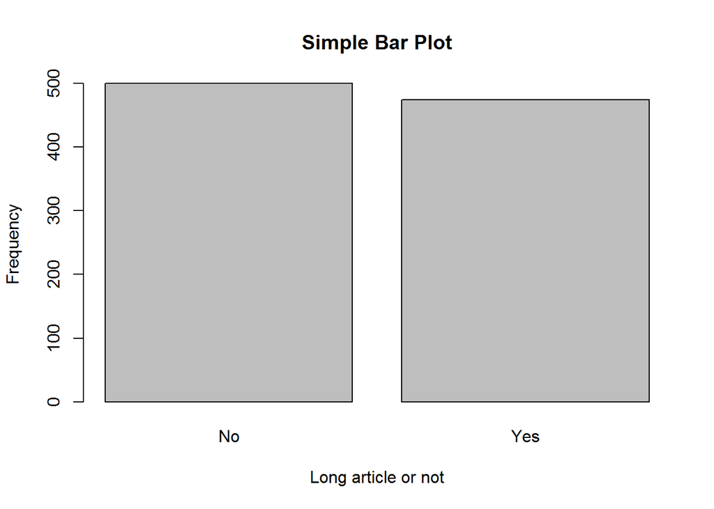

```r
count<-table(tst3$long)
barplot(count,main="Simple Bar Plot",
        xlab="Long article or not", ylab="Frequency")
```

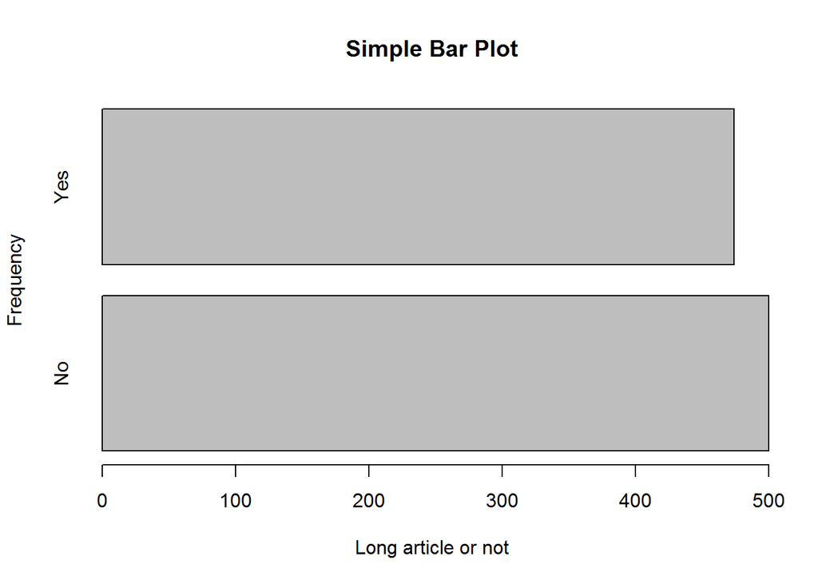

```r
barplot(count,main="Simple Bar Plot",
        xlab="Long article or not", ylab="Frequency", horiz=TRUE)
```

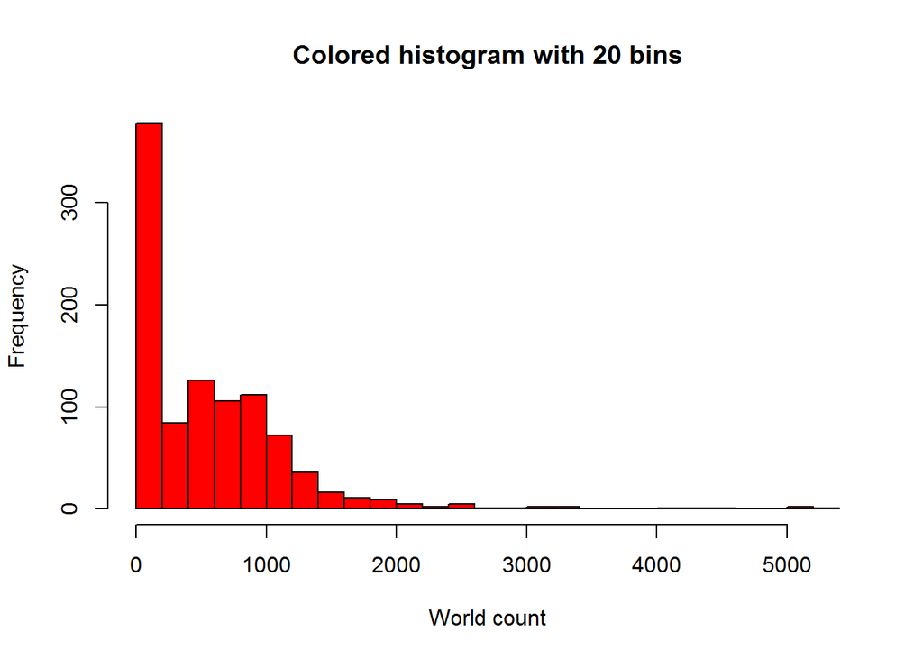

```r
hist(tst3$wc,breaks=20,
     col="red",
     xlab="World count",
     main="Colored histogram with 20 bins")
```

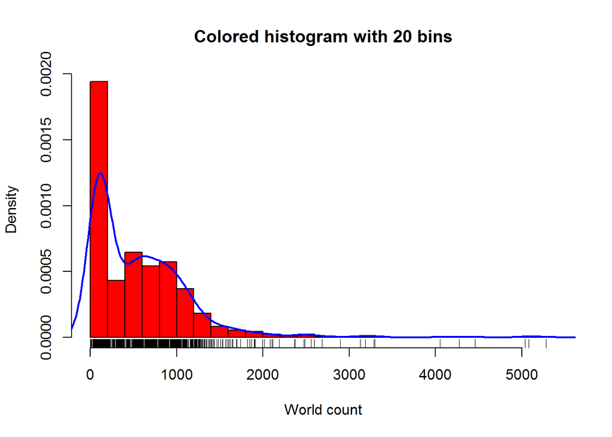

```r
hist(tst3$wc,breaks=20,
     freq = F,
     col="red",
     xlab="World count",
     main="Colored histogram with 20 bins")
rug(jitter(tst3$wc))
lines(density(tst3$wc), col="blue", lwd=2)
```

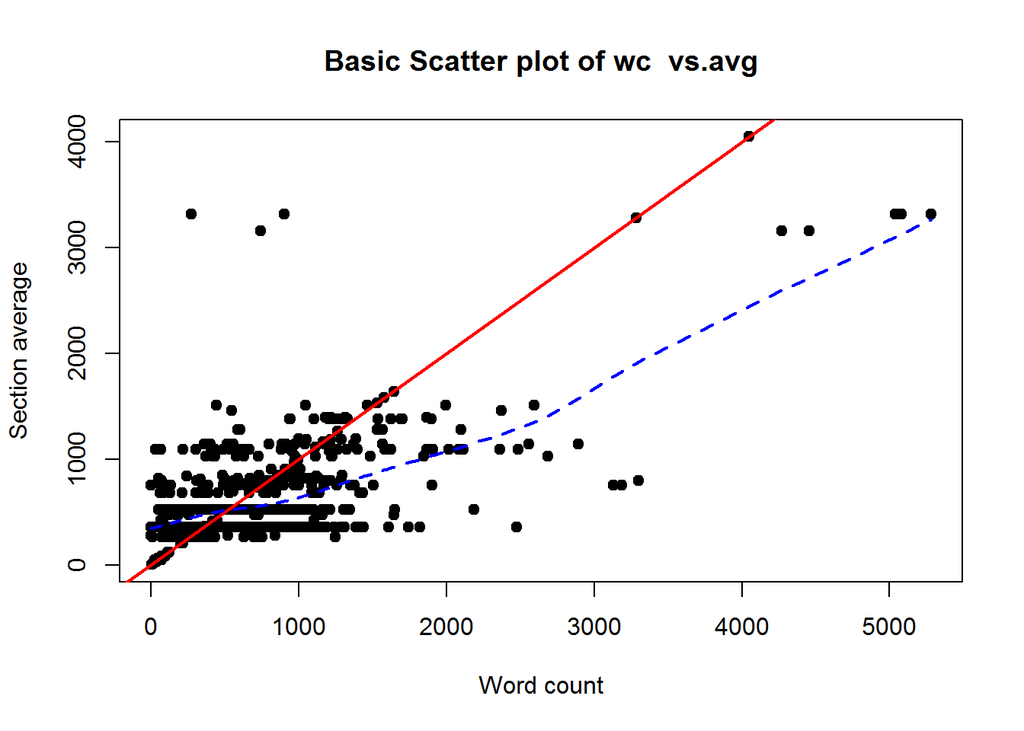

```r
plot(tst3$wc,tst3$avg,
     main="Basic Scatter plot of wc  vs.avg", xlab="Word count",
     ylab="Section average", pch=19)
abline(lm(tst3$wc~tst3$avg), col="red", lwd=2,   lty=1)
lines(lowess(tst3$wc,tst3$avg), col="blue", lwd=2, lty=2)
```